# ma615 midterm slide

10/20/2019

## Introduction

In this report, we look at  
- World urbanization  
- World carbon dioxide emission  
- Relationship between these two variables

All data used are from World Bank database. And we look specifically at 1995 and 2005 to compare and contrast variable values from different countries.

## World urban population

In the graph below, points above the (imaginary)line going through the origin with slope 1 represent countries with growth in urban population percentage from 1995 to 2005.

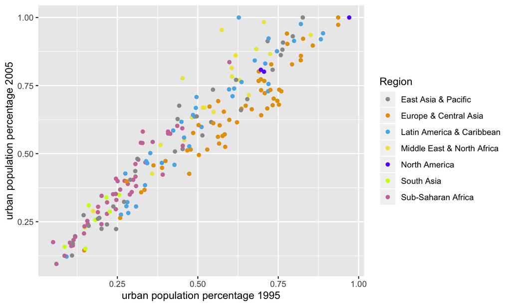

## Boxplot

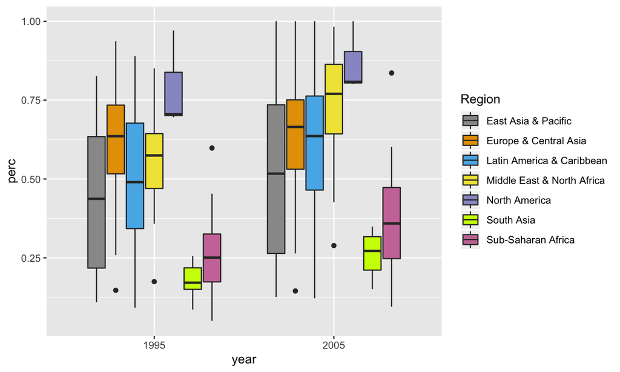

The outliner for Europe & Central Asia Region in 1995 and 2005 is Liechtenstein.  
In Middle East & North Africa, the country with an abnormally low urban population percentage is Yemen, Rep.  
the African country that has an abnormally high urban population percentage in both years is Gabon.

## Countries with high level of urbanization

Below are the 10 countries and areas with the largest urban population percentage.

Countries with Lagest Urban Population %

| 1995 Country | 1995 Urban Population % | 2005 Country | 2005 Urban Population % |
| --- | --- | --- | --- |
| Bermuda | 0.9706 | Bermuda | 1.000 |
| Belgium | 0.9364 | Cayman Islands | 1.000 |
| Monaco | 0.9363 | Monaco | 1.000 |
| Virgin Islands (U.S.) | 0.8893 | Singapore | 1.000 |
| Uruguay | 0.8825 | Kuwait | 0.983 |
| United Kingdom | 0.8574 | Puerto Rico | 0.976 |
| Malta | 0.8508 | Belgium | 0.973 |
| Iceland | 0.8273 | Qatar | 0.954 |
| Singapore | 0.8262 | Virgin Islands (U.S.) | 0.942 |
| Denmark | 0.8205 | San Marino | 0.941 |

## Top 10 growth

Below are the 10 countries with the largest growth in their urban population percentage.

Countries with bigest Increase 1995-2005

| Country | Urban Population % 1995 | Urban Population % 2005 | Increment |
| --- | --- | --- | --- |
| Qatar | 0.57466 | 0.954 | 0.3793 |
| Cayman Islands | 0.62738 | 1.000 | 0.3726 |
| United Arab Emirates | 0.45247 | 0.777 | 0.3245 |
| Kuwait | 0.70538 | 0.983 | 0.2776 |
| Liberia | 0.32908 | 0.581 | 0.2519 |
| Djibouti | 0.61773 | 0.861 | 0.2433 |
| Gabon | 0.59811 | 0.836 | 0.2379 |
| Malaysia | 0.44220 | 0.676 | 0.2338 |
| Angola | 0.32302 | 0.540 | 0.2170 |
| Panama | 0.49598 | 0.708 | 0.2120 |

## Carbon Dioxide Emission Per Capita

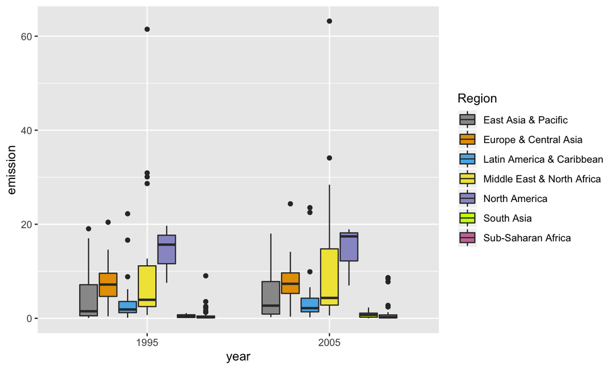

## Urbanization and Carbon Dioxide Emission

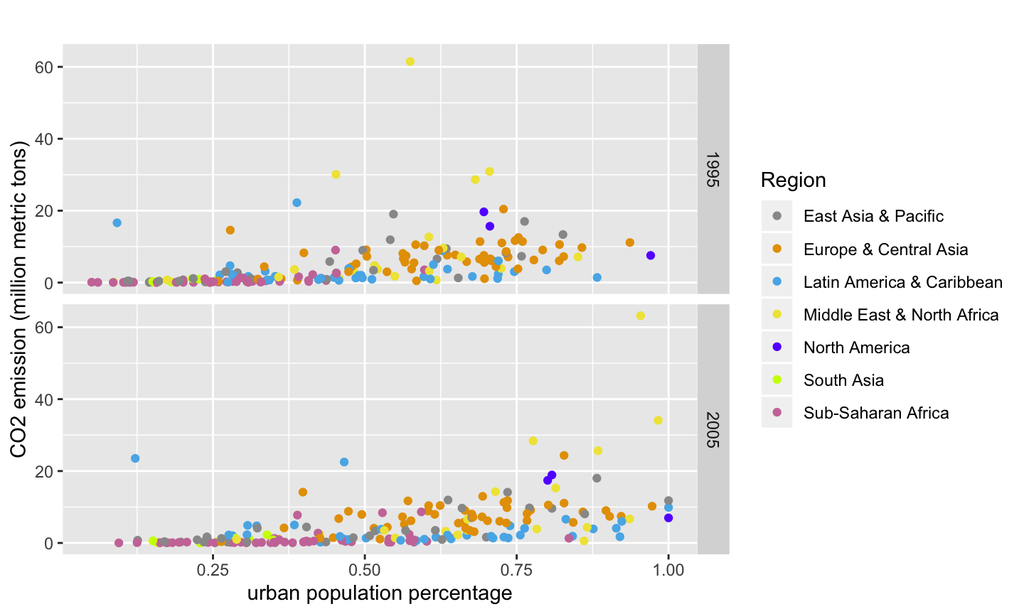

## looking for linear relationship(1995)

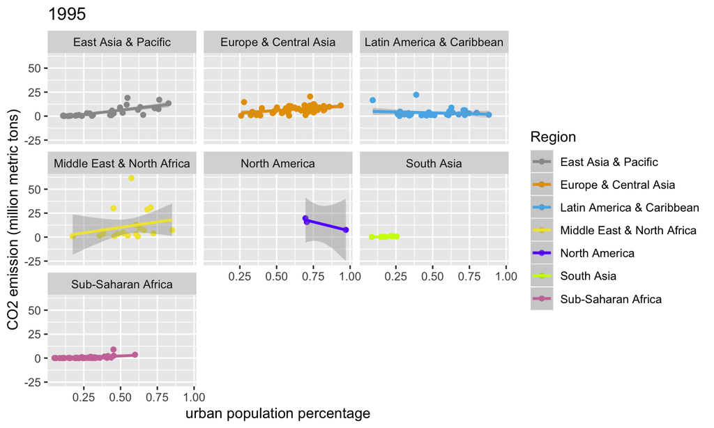

## 2005

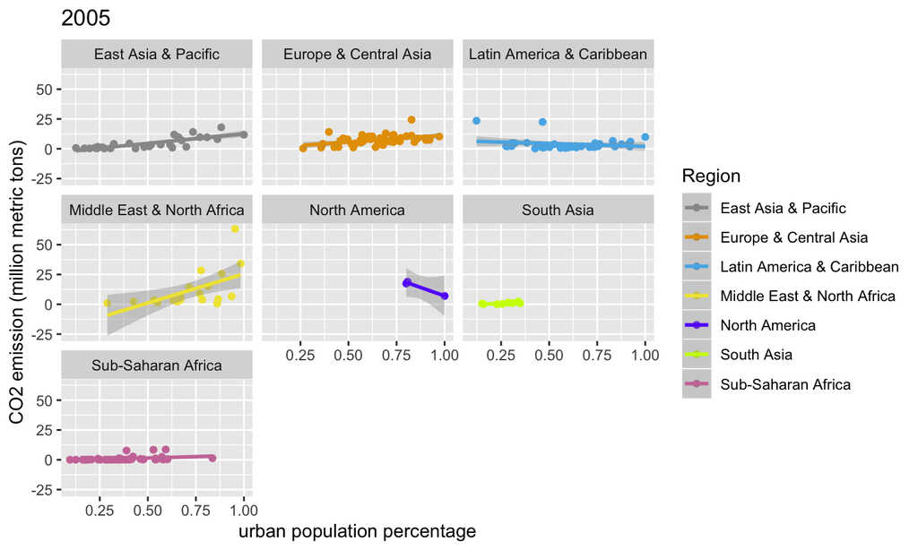